# von Mises vs Fourier directional models

FoMo has two ways to model a preference for moving in some absolute direction (e.g. rightward, or along rows). Both add a term to each item’s log-weight that depends only on the angle from the last selection to that item; they differ in which shapes that term can take.

- **von Mises** (`directional_model = "von_mises"`, the model of Clarke & Hughes, 2026): a weight $\theta$ for each of four fixed directions (right, up, left, down), each a narrow von Mises bump. It can only prefer those four directions, but each weight reads directly as “how much this person likes moving that way”.
- **Fourier** (`directional_model = "fourier"`, the default): a Fourier series in the angle, with a {cos, sin} coefficient pair per harmonic. Harmonic 1 gives one preferred direction, harmonic 2 a preferred axis, harmonic 4 a four-fold pattern. Fourier-124 (harmonics 1, 2 and 4) can put a peak in any direction, but only smooth ones.

We simulate one person twice, once from each model, with realistic values: each model’s estimates for the feature condition of Kristjánsson et al. (2014). Then we fit both models to both datasets, see how well each recovers a shape it wasn’t built for, and compare them.

Code: `fourier_v_vonmises.R`.

```r
source("../../../../functions/set_up_FoMo.R")
```

```
[1] "set_up_FoMo.R: random seed set to 65 (FOMO_SEED)"
```

```r
# sampler settings (the same in every example; set FOMO_EXAMPLE_ITER for a quick run)
n_iter <- as.integer(Sys.getenv("FOMO_EXAMPLE_ITER", "300"))
```

## 1 Simulate

One condition, 100 trials of 40 items each (an 8 x 8 grid with 24 cells empty). The two datasets have almost the same distance and turning biases ($\rho_\delta$, $\rho_\psi$), so they differ mainly in their directional preference.

```r
# one condition, 100 trials of 40 items (an 8 x 8 grid, 24 cells empty),
# as in Kristjansson et al. (2014)
spec <- list(K = 1, nrow = 8, ncol = 8, prop_missing = 0.375, v_type = "none")
stim <- generate_stim(spec, n_trials = 100)
```

We now simulate a von Mises forager $\ldots$

```r
# von Mises: one log-weight (log_theta) each for right, up, left and down.
# Values: the von Mises fit to Kristjansson et al.'s feature condition
sl_sim_vm <- prep_stan_list(stim,
                            list(rho_delta_mu = 2.41,
                                 rho_psi_mu = -2.14,
                                 log_theta_mu = rbind(c(-3.07, -0.10, -5.07, -0.03))),
                            directional_model = "von_mises")
sim_vm <- sim_fomo(sl_sim_vm, iter = 1, chains = 1)
found_vm <- extract_pred(sim_vm, stim)
```

$\ldots$ followed by a Fourier forager:

```r
# Fourier-124: {cos, sin} coefficients for harmonics 1, 2 and 4. Values:
# the Fourier-124 fit to the same data
sl_sim_f <- prep_stan_list(stim,
                           list(rho_delta_mu = 2.50,
                                rho_psi_mu = -2.12,
                                fourier_coef_mu = rbind(c(0.27, 0.04, -0.45, 0.19, 0.16, -0.04))),
                           directional_model = "fourier")
sim_f <- sim_fomo(sl_sim_f, iter = 1, chains = 1)
found_f <- extract_pred(sim_f, stim)
```

Each curve is the directional term’s log-weight for an item at that angle from the last selection, centred on 0 (adding a constant to every item doesn’t change which is chosen, so only the shape matters). The angle 0 is rightward and $\pi/2$ is up. Both prefer vertical moves: von Mises with narrow peaks at up and down on a flat floor, Fourier-124 with broader peaks and dips where horizontal moves are avoided.

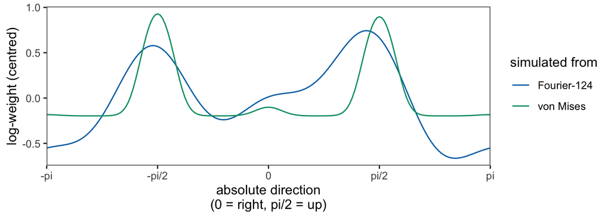

Figure 1: The directional preference each dataset was simulated from.

```r
truth <- list(vm = compute_directional_curve(extract_post(sim_vm, found_vm)),
              f = compute_directional_curve(extract_post(sim_f, found_f)))

bind_rows(`von Mises` = truth$vm, `Fourier-124` = truth$f, .id = "model") |>
  ggplot(aes(angle, log_weight, colour = model)) +
  theme_fomo() +
  geom_line() +
  scale_colour_model() +
  scale_x_direction() +
  labs(y = "log-weight (centred)", colour = "simulated from")
```

## 2 Fit both models to both datasets

```r
# each dataset fitted with each directional model: fit_<data>_<model>
fit_with <- function(found, model) {
  fit_fomo(prep_stan_list(stim,
                          found = found,
                          directional_model = model),
           iter = n_iter, seed = FOMO_SEED)
}

fit_vm_vm <- fit_with(found_vm, "von_mises")
fit_vm_f  <- fit_with(found_vm, "fourier")
fit_f_vm  <- fit_with(found_f, "von_mises")
fit_f_f   <- fit_with(found_f, "fourier")
```

## 3 Parameter recovery

Each dataset fitted with the model that generated it: are the simulation values inside the 97% HPDIs?

```r
# each dataset's own model: are the simulation values inside the 97% HPDIs?
fomo_summary(fit_vm_vm, sim_vm)
```

**Fixed effects (median and 97% HPDI)**

| parameter | condition | component | lower | median | upper | true | inside | rhat | ess_bulk | ess_tail |
| --- | --- | --- | --- | --- | --- | --- | --- | --- | --- | --- |
| rho_delta | 1 |  | 2.30 | 2.39 | 2.50 | 2.41 | TRUE | 1 | 1494 | 1458 |
| rho_psi | 1 |  | -2.29 | -2.08 | -1.84 | -2.15 | TRUE | 1 | 1832 | 1391 |
| log_theta | 1 | 0 | -4.51 | -2.47 | -1.65 | -3.08 | TRUE | 1 | 800 | 502 |
| log_theta | 1 | pi/2 | -0.31 | -0.05 | 0.17 | -0.09 | TRUE | 1 | 1543 | 1500 |
| log_theta | 1 | pi | -6.75 | -3.99 | -2.30 | -5.07 | TRUE | 1 | 1265 | 992 |
| log_theta | 1 | 3*pi/2 | -0.09 | 0.14 | 0.37 | -0.04 | TRUE | 1 | 1750 | 1119 |

Recovery: 6 of 6 (100%) simulation values inside the 97% HPDI; about 97% expected by chance.

Convergence (all parameters): largest R-hat 1.004 (log_theta[1,1]); smallest bulk ESS 800 (log_theta[1,1]), tail ESS 502 (log_theta[1,1]); 0 divergent transitions.

```r
fomo_summary(fit_f_f, sim_f)
```

**Fixed effects (median and 97% HPDI)**

| parameter | condition | component | lower | median | upper | true | inside | rhat | ess_bulk | ess_tail |
| --- | --- | --- | --- | --- | --- | --- | --- | --- | --- | --- |
| rho_delta | 1 |  | 2.39 | 2.50 | 2.60 | 2.51 | TRUE | 1.01 | 3323 | 1764 |
| rho_psi | 1 |  | -2.19 | -1.95 | -1.74 | -2.13 | TRUE | 1.00 | 3119 | 1495 |
| fourier_coef | 1 | h1 cos | 0.27 | 0.34 | 0.43 | 0.28 | TRUE | 1.00 | 3135 | 1468 |
| fourier_coef | 1 | h1 sin | -0.04 | 0.03 | 0.11 | 0.05 | TRUE | 1.00 | 4163 | 1522 |
| fourier_coef | 1 | h2 cos | -0.51 | -0.44 | -0.38 | -0.44 | TRUE | 1.00 | 3841 | 1378 |
| fourier_coef | 1 | h2 sin | 0.16 | 0.25 | 0.34 | 0.20 | TRUE | 1.00 | 3233 | 1278 |
| fourier_coef | 1 | h4 cos | 0.08 | 0.14 | 0.20 | 0.17 | TRUE | 1.00 | 3138 | 1642 |
| fourier_coef | 1 | h4 sin | -0.07 | 0.09 | 0.26 | -0.04 | TRUE | 1.00 | 3510 | 1779 |

Recovery: 8 of 8 (100%) simulation values inside the 97% HPDI; about 97% expected by chance.

Convergence (all parameters): largest R-hat 1.005 (rho_delta[1]); smallest bulk ESS 3119 (rho_psi[1]), tail ESS 1278 (fourier_coef[1,4]); 0 divergent transitions.

## 4 Directional curves

Neither model can match the other’s shape exactly:

- On the von Mises data, Fourier-124 finds both peaks but can’t make them as narrow without adding dips beside them.
- On the Fourier-124 data, von Mises can only add narrow bumps at its four directions onto a flat floor, so it misses the width of the peaks and the dips.

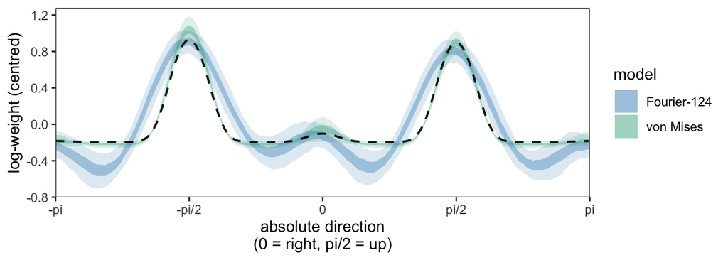

Figure 2: Data simulated from von Mises: the true curve (dashed) and each model’s fit, with 53% and 97% HPDI bands.

```r
bind_rows(`von Mises`   = compute_directional_curve(extract_post(fit_vm_vm, found_vm, stim)),
          `Fourier-124` = compute_directional_curve(extract_post(fit_vm_f, found_vm, stim)),
          .id = "model") |>
  plot_post_directional_curves(truth$vm)
```

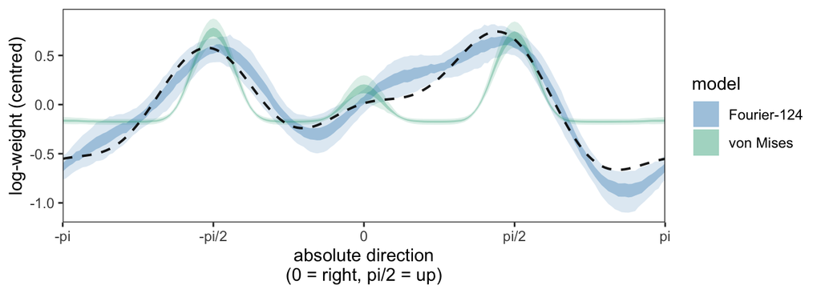

Figure 3: Data simulated from Fourier-124: the true curve (dashed) and each model’s fit, with 53% and 97% HPDI bands.

```r
bind_rows(`von Mises`   = compute_directional_curve(extract_post(fit_f_vm, found_f, stim)),
          `Fourier-124` = compute_directional_curve(extract_post(fit_f_f, found_f, stim)),
          .id = "model") |>
  plot_post_directional_curves(truth$f)
```

## 5 Model comparison

`fomo_compare()` takes the models fitted to one dataset and returns one row per model:

- `deterministic`: how often the model’s most likely item is the one selected; `gain_nn`: its gain over always picking the nearest item
- `elpd_diff`, `se_diff`: how much worse each model predicts left-out trials than the best (loo); within about 2 SE is a tie
- `pct_high_k`: the share of trials whose loo estimate is unreliable (Pareto $k$ above 0.7)
- `stacking`: model weights
- `robust`: whether the best model still wins without the high-$k$ trials

The model the data came from should win. Differences that loo detects clearly can be small in accuracy, because most selections are decided by distance, not direction.

```r
# fomo_compare() compares the models fitted to one dataset: one call each
compare_vm <- fomo_compare(list(`von Mises` = fit_vm_vm, `Fourier-124` = fit_vm_f),
                           data = list(stim = stim, found = found_vm))
compare_f  <- fomo_compare(list(`von Mises` = fit_f_vm, `Fourier-124` = fit_f_f),
                           data = list(stim = stim, found = found_f))

bind_rows(`von Mises data` = compare_vm, `Fourier-124 data` = compare_f, .id = "dataset") |>
  format_compare(columns = c("dataset", "model", "deterministic", "gain_nn", "elpd_diff",
                             "se_diff", "pct_high_k", "stacking", "robust"),
                 group = "dataset")
```

| dataset | model | deterministic | gain_nn | elpd_diff | se_diff | pct_high_k | stacking | robust |
| --- | --- | --- | --- | --- | --- | --- | --- | --- |
| von Mises data | von Mises | 0.714 | 0.069 | 0 | 0.0 | 0 | 1 | TRUE |
| von Mises data | Fourier-124 | 0.714 | 0.068 | -10 | 3.6 | 0 | 0 | TRUE |
| Fourier-124 data | von Mises | 0.705 | 0.060 | -49 | 10.4 | 0 | 0 | TRUE |
| Fourier-124 data | Fourier-124 | 0.711 | 0.065 | 0 | 0.0 | 0 | 1 | TRUE |

## 6 Checking loo with K-fold

loo approximates leaving each trial out without refitting. When that approximation is doubtful, `fomo_compare()` warns, and K-fold cross-validation does it for real: the trials are split into $K$ folds and each model is refitted $K$ times, each time leaving one fold out. Asking for it is one argument, `kfold_cv = 3`; each model is refitted with its own settings. Here, on the von Mises data, the two should tell the same story.

```r
# the same comparison with 3-fold cross-validation (3 fits per model)
kfold_vm <- fomo_compare(list(`von Mises` = fit_vm_vm, `Fourier-124` = fit_vm_f),
                         data = list(stim = stim, found = found_vm), kfold_cv = 3)
format_compare(kfold_vm, columns = c("model", "elpd_diff", "se_diff",
                                     "elpd_diff_kfold", "se_diff_kfold"))
```

| model | elpd_diff | se_diff | elpd_diff_kfold | se_diff_kfold |
| --- | --- | --- | --- | --- |
| von Mises | 0.0 | 0.0 | 0.0 | 0.0 |
| Fourier-124 | -9.5 | 3.6 | -14.6 | 3.6 |